# Loan data exploration

## Multivariate Exploration

> Create plots of three or more variables to investigate your data even further. Make sure that your investigations are justified, and follow from your work in the previous sections.

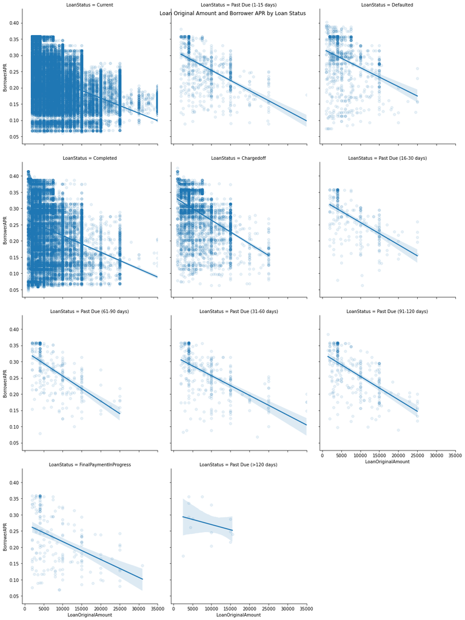

```python
g = sb.FacetGrid(data = df,height=5, col='LoanStatus',col_wrap=3)
g.map(sb.regplot, 'LoanOriginalAmount', 'BorrowerAPR', x_jitter=0.04, scatter_kws={'alpha':0.1});
plt.suptitle('Loan Original Amount and Borrower APR by Loan Status');
```

> There is no insights from these relations.

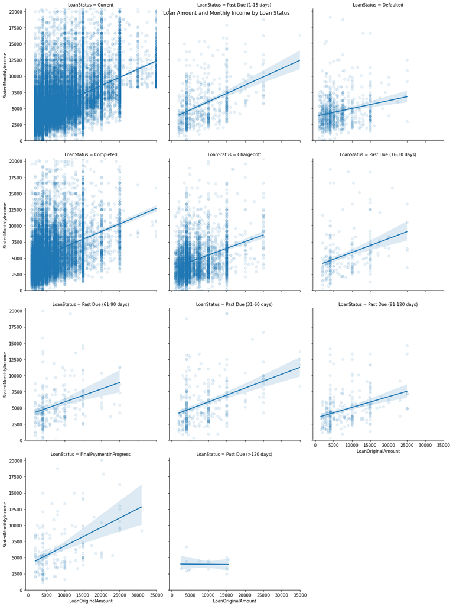

```python
g = sb.FacetGrid(data = df,height=5, col='LoanStatus',col_wrap=3)
g.map(sb.regplot, 'LoanOriginalAmount', 'StatedMonthlyIncome', x_jitter=0.04, scatter_kws={'alpha':0.1});
plt.suptitle('Loan Amount and Monthly Income by Loan Status')
for ax in g.fig.axes:
    ax.set_ylim(0,df.StatedMonthlyIncome.quantile(0.99))
plt.tight_layout();
```

> The relation has positive corelation.

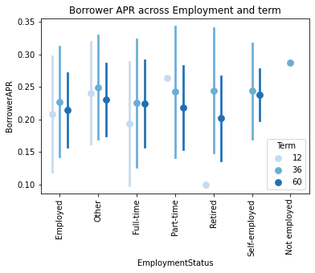

```python
ax = sb.pointplot(data = df, x = 'EmploymentStatus', y = 'BorrowerAPR', hue = 'Term',
           palette = 'Blues', linestyles = '', dodge = 0.4, ci='sd')
plt.title('Borrower APR across Employment and term')
plt.xticks(rotation = 90);
```

> This graph doesn't indicate any relation.

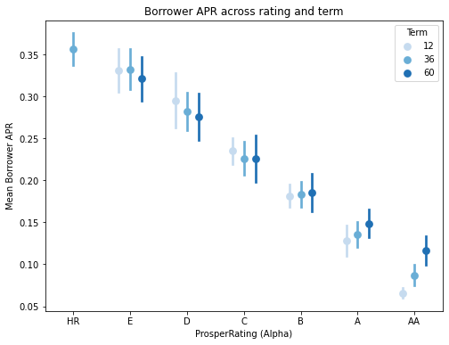

```python
fig = plt.figure(figsize = [8,6])
order2 = ['HR','E','D','C','B','A','AA']

ax = sb.pointplot(data = df, x = 'ProsperRating (Alpha)', y = 'BorrowerAPR', hue = 'Term',
           palette = 'Blues', linestyles = '', dodge = 0.4, ci='sd',order=order2)
plt.title('Borrower APR across rating and term')
plt.ylabel('Mean Borrower APR')
ax.set_yticklabels([],minor = True);
```

> This distribution is divided into two parts , The borrower APR decreases with the no of terms with rating from HR-C but in the other part from C to AA the borrower APR increases with no of terms.

### Talk about some of the relationships you observed in this part of the investigation. Were there features that strengthened each other in terms of looking at your feature(s) of interest?

> As observed from bivariate relations , the loan status depends onn the stated monthly income ,debt to income ratio.'.

### Were there any interesting or surprising interactions between features?

> yes ,The borrower APR decreases with the no of terms with rating from HR-C but in the other part from C to AA the borrower APR increases with no of terms.

> At the end of your report, make sure that you export the notebook as an html file from the `File > Download as... > HTML` menu. Make sure you keep track of where the exported file goes, so you can put it in the same folder as this notebook for project submission. Also, make sure you remove all of the quote-formatted guide notes like this one before you finish your report!

```python
# save the cleaned dataset for explanatory data analysis
df.to_csv('df_cleaned.csv')
```